# Predicting spadefoot toad environmental niche using random forest and xgboost in R

Kevin Neal

November 13, 2019

## What is Environmental Niche Modeling (i.e Species Distribution Modeling)?

- predict habitat suitability or likelihood of occupancy for a species based on known occurrences and environmental data
- useful for:
  - predicting new localities
  - understanding biological niche space and environmental variables that contribute to creating this space
  - predicting past and future distributions
- Personal usage: compared model-derived niche space to provide evidence for splitting a species of spadefoot toad into two (Neal et al. 2018)

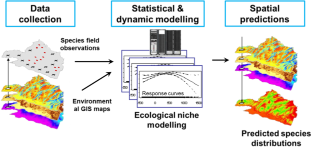

Species Distribution Modeling

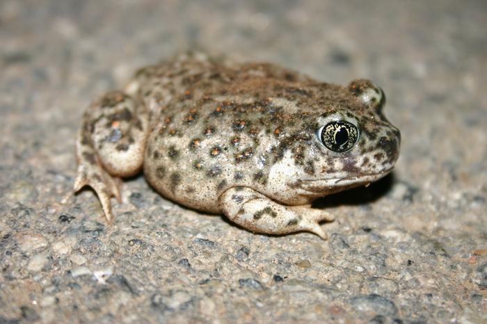

Spea hammondii (western spadefoot toad)

**Response variable: binary presence (1) or absence (0)**

**Predictor environmental variables:** Various sources derived from precipitation and temperature, as well as soil and topography

### Data wrangling: Filtering presence points

- First, want to filter points that may lie outside the study area or have erroneous coordinates (e.g. the point is in the ocean)
- Want a balanced response variable - while spatial samples may accurately reflect species density, more likely it reflects search effort, so we want to filter the points
- This can be distance/radius-based or based on other aspects of the localities if we have the metadata
- Here we’ll sample points using a grid, with one sample point per grid cell

```r
# load points and rasters, filter points, make background/pseudoabsence points
# points from GBIF, Bison, iNaturalist, and Shaffer lab collections
# coords last updated in 2017
present <- read.csv("speahammondii_combined_presence_points.csv")
head(present)
```

|  | Species | Longitude | Latitude |
| --- | --- | --- | --- |
| 1 | Spea_hammondii_S | -115.6091 | 30.12889 |
| 2 | Spea_hammondii_S | -115.7599 | 30.19903 |
| 3 | Spea_hammondii_S | -115.9500 | 30.76833 |
| 4 | Spea_hammondii_S | -115.9506 | 30.76841 |
| 5 | Spea_hammondii_S | -115.7333 | 30.96667 |
| 6 | Spea_hammondii_S | -116.2017 | 31.06722 |

```r
#dim(present)
#dim(unique(present))
```

```r
socalstack <- stack(list.files(path="./socal_rasters/", pattern="asc$", full.names = TRUE))
socalfilenames <- list.files(path="./socal_rasters/", pattern="asc$", full.names = FALSE)
socalnames <- gsub(pattern="_.*asc", replacement="", socalfilenames)
names(socalstack) <- socalnames

pres.sub <- crop(SpatialPoints(present[,2:3]), socalstack[[1]])

# subsample presence points by a lower-resolution grid

#pres.thin <- gridSample(pres.sub, r=socalstack[[1]])
pres.thin <- gridSample(pres.sub, r=aggregate(socalstack[[1]], fact=3), n=1)

plot(socalstack[[1]], col=viridis(20), main="Spatially subsampled toad presences")
points(pres.sub, pch=4, col="red")
```

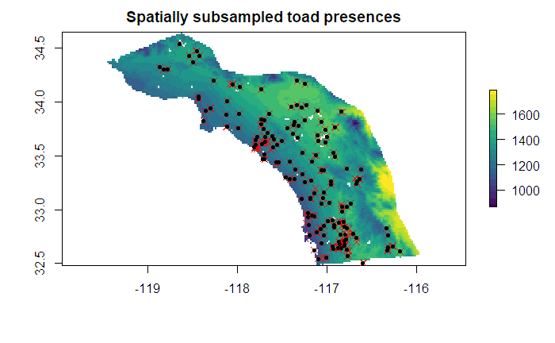

```r
points(pres.thin, pch=20, col="black")
```

```r
NA
NA
NA
```

### Generating pseudoabsences

```r
# take a random sample of the background, excluding cells that contain presence points, by masking the raster by the SpatialPoints object

# want a lot of pseudoabsences to get a full representation of the environmental conditions
# subsample by lower-resolution grid

absent <- randomPoints(mask=mask(aggregate(socalstack[[1]], fact=3),
                       buffer(pres.sub, #buffer(SpatialPoints(present[,2:3]),
                       width=10000), inverse=T),
                       n=nrow(pres.thin), #keeps classes balanced; higher number would lead to imbalanced classes but more coverage of the space of environmental variable combinations in the region
                       p=SpatialPoints(present[,2:3]),
                       excludep=TRUE)
#nrow(gridSample(absent, socalstack[[1]]))

abs.thin <- gridSample(absent, r=socalstack[[1]])
```

```r
plot(absent, pch=4, col="red")
points(abs.thin, col="blue")
```

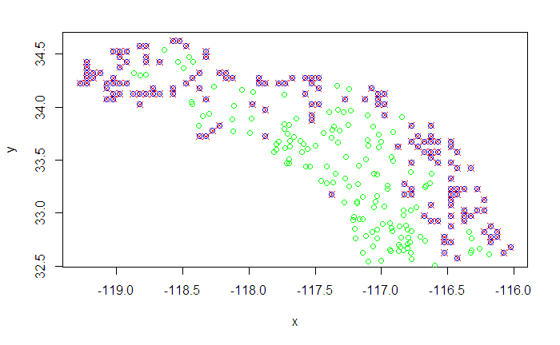

```r
points(pres.thin, col="green")
```

```r
#points
```

```r
# randomly select from the absences equal to presences to have balanced set
## not needed if n=length(pres.thin) in generating random points
#set.seed(1)
#rows_to_sample <- sample(1:nrow(), nrow(pres.thin))
#abs.thin <- abs.thin[rows_to_sample,] # sample random rows without replacement
#dim(abs.thin)
```

### Combine presence and absence points into a single dataframe

```r
# make dataframes specifying point type (present=1, absent=0)
presabs <- dplyr::union(
  data.frame(pa="present", Longitude=pres.thin[,1], Latitude=pres.thin[,2]),
  data.frame(pa="absent", Longitude=abs.thin[,1], Latitude=abs.thin[,2])
  )
```

```
Column `pa` joining factors with different levels, coercing to character vector
```

```r
presabs[,1] <- as.factor(presabs[,1])
presabs[,1] <- factor(presabs[,1], levels=rev(levels(presabs[,1])))
head(presabs)
```

|  | pa | Longitude | Latitude |
| --- | --- | --- | --- |
| 1 | present | -116.5959 | 32.50397 |
| 2 | present | -117.0961 | 32.54112 |
| 3 | present | -117.0025 | 32.55306 |
| 4 | present | -116.7722 | 32.56694 |
| 5 | present | -116.1840 | 32.61200 |
| 6 | present | -116.7759 | 32.62487 |

### Extract values (predictor variables/features) from environmental layers at each presence and absence point

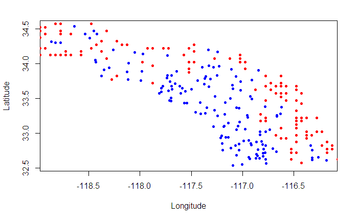

```r
# drop features related to urbanization - want the "natural" niche of the species
socalstack <- dropLayer(socalstack, c("canopy", "impervious"))

# extract environmental data at each point
presabs.envdata <- raster::extract(socalstack, presabs[,2:3])
presabs.data <- bind_cols(data.frame(presabs), data.frame(presabs.envdata))

# remove rows with missing data (i.e. points that don't fall on the map)
presabs.data <- presabs.data[complete.cases(presabs.data),]

plot(presabs.data[presabs.data$pa=="present",c(2,3)], col="blue", pch=20)
points(presabs.data[presabs.data$pa=="absent",c(2,3)], col="red", pch=20)
```

```r
NA
NA
```

### Remove highly correlated features

- Inclusion of highly correlated features can bias the models and produce misleading feature importances
- Multiple ways to select features; I’ll use findCorrelation in caret to do pairwise removal of variables with spearman’s rho above 0.7

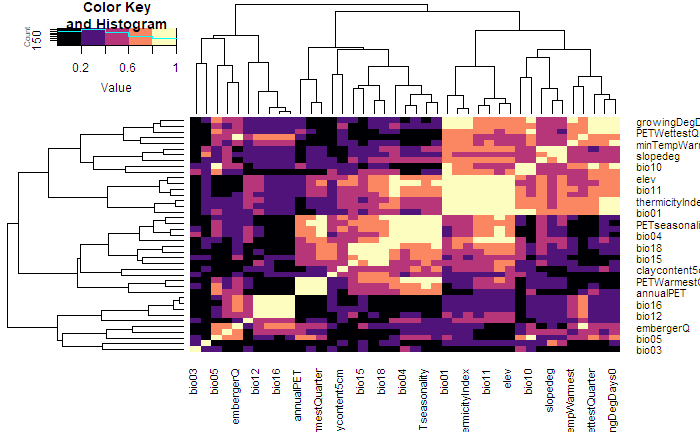

```r
# use caret::findCorrelation to remove correlated variables
# could also use boruta or another mutual information method
library(corrplot)
library(gplots)

heatmap.2(abs(cor(presabs.data[,-c(1:3)], method="spearman")), symm=T, col=magma(5), trace="none")
```

```r
remove.vars <- findCorrelation(cor(presabs.data[,-c(1:3)], method="spearman"), cutoff=0.7, names=TRUE, verbose=F)
presabs.data.sel <- presabs.data[, !names(presabs.data) %in% remove.vars] # remove the correlated variables
```

```r
# remove variables from the raster stack
#socalstack.sub <- subset(socalstack, names(socalstack)[!names(socalstack) %in% remove.vars])
socalstack_sub <- subset(socalstack, setdiff(names(socalstack), remove.vars))
names(socalstack_sub)
```

```
 [1] "aridityIndexThornthwaite" "bio03"                    "bio05"
 [4] "bio09"                    "bio14"                    "bio16"
 [7] "bulkdensity5cm"           "claycontent5cm"           "depthtobedrockrhorizon"
[10] "embergerQ"                "minTempWarmest"           "PETDriestQuarter"
[13] "siltcontent5cm"           "slopedeg"
```

```r
# this is the complete dataframe that will be the input in the models
```

### Exploratory data analysis

- Qualitatively, do any features show clear discrimination between our two response classes (presence and absence)?

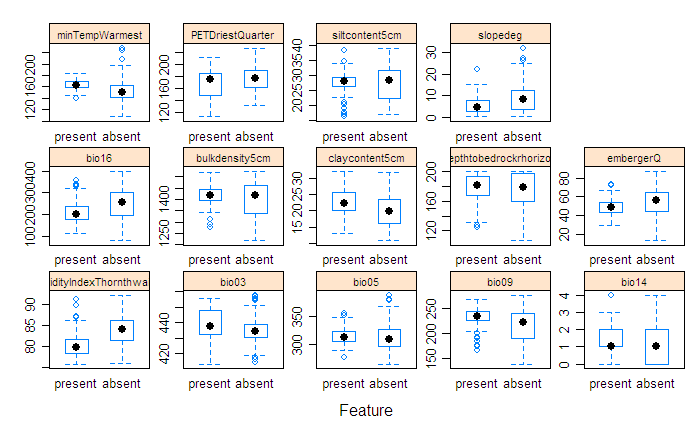

```r
# examine distribution of feature values by class
featurePlot(x = presabs.data.sel[, -c(1:3)],
            y = presabs.data.sel$pa, # must be factor
            plot = "box",
            strip=strip.custom(par.strip.text=list(cex=.7)),
            scales = list(x = list(relation="free"),
                          y = list(relation="free")),
            auto.key=TRUE)
```

### Modelling using caret

```r
# run models using caret, starting with xgboost, then ranger/rf


xgb_trcontrol = trainControl(
  method = "repeatedcv",
  number = 5,
  repeats = 2,
  allowParallel = TRUE,
  verboseIter = FALSE,
  returnData = FALSE,
  classProbs = TRUE,
  savePredictions = TRUE,
  summaryFunction = twoClassSummary #use with metric="ROC" in train(); or use prSummary with AUC
  #summaryFunction = prSummary
  #sampling="down"
)
```

```r
#trainall <- allpts.thin.data
#trainall[,1] <- make.names(trainall[,1])

modelLookup("xgbTree")
```

|  | model | parameter | label | forReg | forClass | probModel |
| --- | --- | --- | --- | --- | --- | --- |
| 1 | xgbTree | nrounds | # Boosting Iterations | TRUE | TRUE | TRUE |
| 2 | xgbTree | max_depth | Max Tree Depth | TRUE | TRUE | TRUE |
| 3 | xgbTree | eta | Shrinkage | TRUE | TRUE | TRUE |
| 4 | xgbTree | gamma | Minimum Loss Reduction | TRUE | TRUE | TRUE |
| 5 | xgbTree | colsample_bytree | Subsample Ratio of Columns | TRUE | TRUE | TRUE |
| 6 | xgbTree | min_child_weight | Minimum Sum of Instance Weight | TRUE | TRUE | TRUE |
| 7 | xgbTree | subsample | Subsample Percentage | TRUE | TRUE | TRUE |

```r
xgb.grid.large <- expand.grid(nrounds = c(100, 500), # default
                         eta = c(0.1,0.5), # default
                         max_depth = c(3,6,9,12),
                         gamma=0, # default
                         colsample_bytree=1, # default
                         min_child_weight=1, # default
                         subsample=1 # default
                         )


set.seed(99)
xgb_caret <- train(x=presabs.data.sel[,-c(1:3)],
                   y=presabs.data.sel[,1],
                   trControl=xgb_trcontrol,
                   method="xgbTree",
                   tuneGrid=xgb.grid.large,
                   metric="ROC", #"AUC"
                   #metric="AUC"
                   importance="permutation")
```

```r
#xgb_caret
```

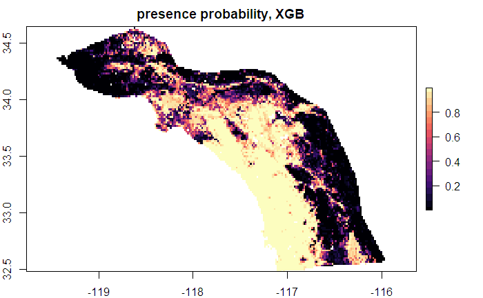

```r
xgb_predtest_prob <- raster::predict(socalstack_sub, xgb_caret, type="prob") # shows class assignment by default; use type="prob" to show class prob

par(mar=c(2,2,2,1))
plot(xgb_predtest_prob, col=magma(20), main="presence probability, XGB")
```

```r
# library(rasterVis)
# levelplot(xgb_predtest_prob, par.settings=rasterTheme(parula(20)))
```

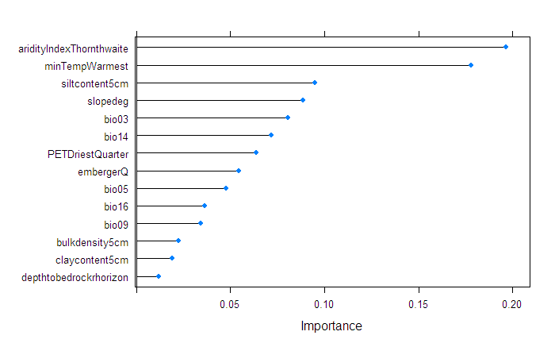

```r
plot(varImp(xgb_caret, scale=F)) # shows gain by default, analogous to impurity for RF
```

```r
twoClassSummary(data=xgb_caret$pred, lev=levels(xgb_caret$pred$obs))
```

```
      ROC      Sens      Spec
0.9118296 0.8350694 0.8095472
```

```r
prSummary(data=xgb_caret$pred, lev=levels(xgb_caret$pred$obs))
```

```
      AUC Precision    Recall         F
0.9302095 0.8325400 0.8350694 0.8338028
```

```r
confusionMatrix(xgb_caret)
```

```
Cross-Validated (5 fold, repeated 2 times) Confusion Matrix

(entries are percentual average cell counts across resamples)

          Reference
Prediction present absent
   present    45.2    8.5
   absent      7.9   38.4

 Accuracy (average) : 0.8358
```

```r
#prSummary(xgb_caret)
```

```r
#modelLookup("ranger")
rf.grid <- expand.grid(
  mtry = c(3,4,6,12),
  splitrule = c("gini", "extratrees"),
  min.node.size = c(2,5,10)
)

set.seed(99)
ranger_caret <- train(x=presabs.data.sel[,-c(1:3)],
                   num.trees=500,
                   y=presabs.data.sel[,1],
                   trControl=xgb_trcontrol,
                   method="ranger",
                   tuneGrid=rf.grid,
                   metric="ROC", #"AUC",
                   #metric="AUC",
                   importance="permutation")

ranger_caret
```

```
Random Forest

No pre-processing
Resampling: Cross-Validated (5 fold, repeated 2 times)
Summary of sample sizes: 216, 216, 218, 217, 217, 217, ...
Resampling results across tuning parameters:

  mtry  splitrule   min.node.size  ROC        Sens       Spec
   3    gini         2             0.9205995  0.7980296  0.8430769
   3    gini         5             0.9204953  0.7911330  0.8389231
   3    gini        10             0.9173056  0.7874384  0.8387692
   3    extratrees   2             0.9393907  0.8640394  0.8273846
   3    extratrees   5             0.9328882  0.8432266  0.8275385
   3    extratrees  10             0.9308077  0.8433498  0.8310769
   4    gini         2             0.9179922  0.7806650  0.8387692
   4    gini         5             0.9182476  0.8014778  0.8390769
   4    gini        10             0.9146819  0.7770936  0.8427692
   4    extratrees   2             0.9367201  0.8363300  0.8313846
   4    extratrees   5             0.9358225  0.8397783  0.8352308
   4    extratrees  10             0.9280091  0.8360837  0.8233846
   6    gini         2             0.9154873  0.7980296  0.8392308
   6    gini         5             0.9166883  0.7945813  0.8467692
   6    gini        10             0.9131690  0.7841133  0.8389231
   6    extratrees   2             0.9370792  0.8363300  0.8276923
   6    extratrees   5             0.9321819  0.8293103  0.8273846
   6    extratrees  10             0.9274322  0.8327586  0.8429231
  12    gini         2             0.9145142  0.7948276  0.8507692
  12    gini         5             0.9071811  0.7977833  0.8350769
  12    gini        10             0.9078283  0.7806650  0.8390769
  12    extratrees   2             0.9349134  0.8399015  0.8235385
  12    extratrees   5             0.9339704  0.8363300  0.8235385
  12    extratrees  10             0.9266739  0.8153941  0.8350769

ROC was used to select the optimal model using the largest value.
The final values used for the model were mtry = 3, splitrule = extratrees and min.node.size = 2.
```

```r
ranger_predtest_bin <- raster::predict(socalstack_sub, ranger_caret, type="class")
```

```
Error in predict.train(model, blockvals, ...) :
  type must be either "raw" or "prob"
```

```r
varImp(ranger_caret, scale=F)
```

```
ranger variable importance
```

|  | Overall |
| --- | --- |
| minTempWarmest | 0.042378700 |
| aridityIndexThornthwaite | 0.041448979 |
| bio09 | 0.032990126 |
| bio16 | 0.032871158 |
| siltcontent5cm | 0.031406126 |
| embergerQ | 0.027414252 |
| bio14 | 0.020515707 |
| slopedeg | 0.018912867 |
| bio03 | 0.018172649 |
| bio05 | 0.016413078 |

[output cut: 4 more lines]

```r
twoClassSummary(data=ranger_caret$finalModel$predictions, lev=levels(ranger_caret$pred$obs))
```

```
Error: $ operator is invalid for atomic vectors
```

```r
confusionMatrix(ranger_caret)
```

```
Cross-Validated (5 fold, repeated 2 times) Confusion Matrix

(entries are percentual average cell counts across resamples)

          Reference
Prediction present absent
   present    45.9    8.1
   absent      7.2   38.7

 Accuracy (average) : 0.8469
```

### Visual comparison of predictions

```r
#par(mfrow=c(1,1))
par(mfrow=c(2,2))
par(mar=c(2,2,2,1))
plot(xgb_predtest_prob, col=magma(20), main="presence probability, XGB")
points(presabs.data.sel[presabs.data.sel$pa=="present",][,c(2,3)])
```

```r
plot(ranger_predtest_prob, col=magma(20), main="presence probability, ranger RF")
points(presabs.data.sel[presabs.data.sel$pa=="present",][,c(2,3)])
```

[output not shown]

```r
plot(2-xgb_predtest_bin, col=magma(20), main="presence (binary), XGB")
points(presabs.data.sel[presabs.data.sel$pa=="present",][,c(2,3)], col="red")
```

[output not shown]

```r
plot(2-ranger_predtest_bin, col=magma(20), main="presence (binary), ranger RF")
points(presabs.data.sel[presabs.data.sel$pa=="present",][,c(2,3)], col="red")
```

[output not shown]

[figure not shown]

```r
par(mfrow=c(1,1))
```

```r
results <- resamples(list(XGB=xgb_caret, RF=ranger_caret))
# summarize the distributions
summary(results)
```

```
Call:
summary.resamples(object = results)

Models: XGB, RF
Number of resamples: 10

ROC
         Min.   1st Qu.    Median      Mean  3rd Qu.      Max. NA's
XGB 0.8368700 0.8920742 0.9362599 0.9216614 0.949748 0.9682759    0
RF  0.8567639 0.9179926 0.9531034 0.9393907 0.962931 0.9748011    0

Sens
         Min.   1st Qu.    Median      Mean   3rd Qu.      Max. NA's
XGB 0.7241379 0.8214286 0.8448276 0.8504926 0.8965517 0.9655172    0
RF  0.7500000 0.8229680 0.8620690 0.8640394 0.9224138 0.9655172    0

Spec
         Min.   1st Qu.    Median      Mean   3rd Qu.      Max. NA's
XGB 0.6153846 0.8019231 0.8400000 0.8193846 0.8715385 0.9200000    0
RF  0.6538462 0.7480769 0.8630769 0.8273846 0.9200000 0.9230769    0
```

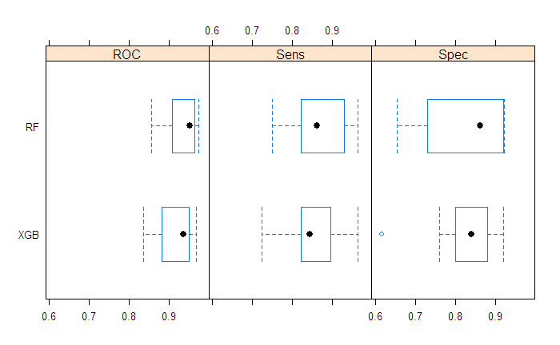

```r
# boxplots of results
bwplot(results)
```